# Risk Factor Analysis

## Outcome Variable

**Outcome Variable:** y_rate_len

## Predictor Variables

**Intervention Variable:** safeh20

**Adjustment Set:**

- arm
- sex
- W_mage
- meducyrs
- feducyrs
- hhwealth_quart
- hfoodsec
- W_mhtcm
- W_mwtkg
- W_mbmi
- W_nrooms
- W_nchldlt5
- impfloor
- impsan
- delta_W_mage
- delta_meducyrs
- delta_feducyrs
- delta_hhwealth_quart
- delta_hfoodsec
- delta_W_mhtcm
- delta_W_mwtkg
- delta_W_mbmi
- delta_W_nrooms
- delta_W_nchldlt5
- delta_impfloor
- delta_impsan

## Stratifying Variables

The analysis was stratified on these variable(s):

- agecat
- studyid
- country

## Data Summary

| agecat | studyid | country | safeh20 | n_cell | n |
| --- | --- | --- | --- | --- | --- |
| 0-3 months | CONTENT | PERU | 1 | 5 | 6 |
| 0-3 months | CONTENT | PERU | 0 | 1 | 6 |
| 0-3 months | JiVitA-3 | BANGLADESH | 1 | 19828 | 19862 |
| 0-3 months | JiVitA-3 | BANGLADESH | 0 | 34 | 19862 |
| 0-3 months | JiVitA-4 | BANGLADESH | 1 | 1805 | 1805 |
| 0-3 months | JiVitA-4 | BANGLADESH | 0 | 0 | 1805 |
| 0-3 months | MAL-ED | BANGLADESH | 1 | 0 | 236 |
| 0-3 months | MAL-ED | BANGLADESH | 0 | 236 | 236 |
| 0-3 months | MAL-ED | BRAZIL | 1 | 0 | 116 |
| 0-3 months | MAL-ED | BRAZIL | 0 | 116 | 116 |
| 0-3 months | MAL-ED | INDIA | 1 | 0 | 177 |
| 0-3 months | MAL-ED | INDIA | 0 | 177 | 177 |
| 0-3 months | MAL-ED | NEPAL | 1 | 1 | 153 |
| 0-3 months | MAL-ED | NEPAL | 0 | 152 | 153 |
| 0-3 months | MAL-ED | PERU | 1 | 11 | 243 |
| 0-3 months | MAL-ED | PERU | 0 | 232 | 243 |
| 0-3 months | MAL-ED | SOUTH AFRICA | 1 | 31 | 196 |
| 0-3 months | MAL-ED | SOUTH AFRICA | 0 | 165 | 196 |
| 0-3 months | MAL-ED | TANZANIA, UNITED REPUBLIC OF | 1 | 155 | 224 |
| 0-3 months | MAL-ED | TANZANIA, UNITED REPUBLIC OF | 0 | 69 | 224 |
| 0-3 months | NIH-Birth | BANGLADESH | 1 | 564 | 566 |
| 0-3 months | NIH-Birth | BANGLADESH | 0 | 2 | 566 |
| 0-3 months | NIH-Crypto | BANGLADESH | 1 | 721 | 721 |
| 0-3 months | NIH-Crypto | BANGLADESH | 0 | 0 | 721 |
| 0-3 months | PROVIDE | BANGLADESH | 1 | 13 | 13 |
| 0-3 months | PROVIDE | BANGLADESH | 0 | 0 | 13 |
| 3-6 months | CONTENT | PERU | 1 | 54 | 57 |
| 3-6 months | CONTENT | PERU | 0 | 3 | 57 |
| 3-6 months | JiVitA-3 | BANGLADESH | 1 | 12562 | 12574 |
| 3-6 months | JiVitA-3 | BANGLADESH | 0 | 12 | 12574 |

[output cut: 182 more lines]

The following strata were considered:

- agecat: 0-3 months, studyid: CONTENT, country: PERU
- agecat: 0-3 months, studyid: JiVitA-3, country: BANGLADESH
- agecat: 0-3 months, studyid: JiVitA-4, country: BANGLADESH
- agecat: 0-3 months, studyid: MAL-ED, country: BANGLADESH
- agecat: 0-3 months, studyid: MAL-ED, country: BRAZIL
- agecat: 0-3 months, studyid: MAL-ED, country: INDIA
- agecat: 0-3 months, studyid: MAL-ED, country: NEPAL
- agecat: 0-3 months, studyid: MAL-ED, country: PERU
- agecat: 0-3 months, studyid: MAL-ED, country: SOUTH AFRICA
- agecat: 0-3 months, studyid: MAL-ED, country: TANZANIA, UNITED REPUBLIC OF
- agecat: 0-3 months, studyid: NIH-Birth, country: BANGLADESH
- agecat: 0-3 months, studyid: NIH-Crypto, country: BANGLADESH
- agecat: 0-3 months, studyid: PROVIDE, country: BANGLADESH
- agecat: 12-15 months, studyid: CONTENT, country: PERU
- agecat: 12-15 months, studyid: JiVitA-4, country: BANGLADESH
- agecat: 12-15 months, studyid: LCNI-5, country: MALAWI
- agecat: 12-15 months, studyid: MAL-ED, country: BANGLADESH
- agecat: 12-15 months, studyid: MAL-ED, country: BRAZIL
- agecat: 12-15 months, studyid: MAL-ED, country: INDIA
- agecat: 12-15 months, studyid: MAL-ED, country: NEPAL
- agecat: 12-15 months, studyid: MAL-ED, country: PERU
- agecat: 12-15 months, studyid: MAL-ED, country: SOUTH AFRICA
- agecat: 12-15 months, studyid: MAL-ED, country: TANZANIA, UNITED REPUBLIC OF
- agecat: 12-15 months, studyid: NIH-Birth, country: BANGLADESH
- agecat: 12-15 months, studyid: NIH-Crypto, country: BANGLADESH
- agecat: 12-15 months, studyid: PROVIDE, country: BANGLADESH
- agecat: 12-15 months, studyid: SAS-FoodSuppl, country: INDIA
- agecat: 15-18 months, studyid: CONTENT, country: PERU
- agecat: 15-18 months, studyid: JiVitA-4, country: BANGLADESH
- agecat: 15-18 months, studyid: LCNI-5, country: MALAWI
- agecat: 15-18 months, studyid: MAL-ED, country: BANGLADESH
- agecat: 15-18 months, studyid: MAL-ED, country: BRAZIL
- agecat: 15-18 months, studyid: MAL-ED, country: INDIA
- agecat: 15-18 months, studyid: MAL-ED, country: NEPAL
- agecat: 15-18 months, studyid: MAL-ED, country: PERU
- agecat: 15-18 months, studyid: MAL-ED, country: SOUTH AFRICA
- agecat: 15-18 months, studyid: MAL-ED, country: TANZANIA, UNITED REPUBLIC OF
- agecat: 15-18 months, studyid: NIH-Birth, country: BANGLADESH
- agecat: 15-18 months, studyid: NIH-Crypto, country: BANGLADESH
- agecat: 15-18 months, studyid: PROVIDE, country: BANGLADESH
- agecat: 15-18 months, studyid: SAS-FoodSuppl, country: INDIA
- agecat: 18-21 months, studyid: CONTENT, country: PERU
- agecat: 18-21 months, studyid: LCNI-5, country: MALAWI
- agecat: 18-21 months, studyid: MAL-ED, country: BANGLADESH
- agecat: 18-21 months, studyid: MAL-ED, country: BRAZIL
- agecat: 18-21 months, studyid: MAL-ED, country: INDIA
- agecat: 18-21 months, studyid: MAL-ED, country: NEPAL
- agecat: 18-21 months, studyid: MAL-ED, country: PERU
- agecat: 18-21 months, studyid: MAL-ED, country: SOUTH AFRICA
- agecat: 18-21 months, studyid: MAL-ED, country: TANZANIA, UNITED REPUBLIC OF
- agecat: 18-21 months, studyid: NIH-Birth, country: BANGLADESH
- agecat: 18-21 months, studyid: NIH-Crypto, country: BANGLADESH
- agecat: 18-21 months, studyid: PROVIDE, country: BANGLADESH
- agecat: 21-24 months, studyid: CONTENT, country: PERU
- agecat: 21-24 months, studyid: LCNI-5, country: MALAWI
- agecat: 21-24 months, studyid: MAL-ED, country: BANGLADESH
- agecat: 21-24 months, studyid: MAL-ED, country: BRAZIL
- agecat: 21-24 months, studyid: MAL-ED, country: INDIA
- agecat: 21-24 months, studyid: MAL-ED, country: NEPAL
- agecat: 21-24 months, studyid: MAL-ED, country: PERU
- agecat: 21-24 months, studyid: MAL-ED, country: SOUTH AFRICA
- agecat: 21-24 months, studyid: MAL-ED, country: TANZANIA, UNITED REPUBLIC OF
- agecat: 21-24 months, studyid: NIH-Birth, country: BANGLADESH
- agecat: 21-24 months, studyid: NIH-Crypto, country: BANGLADESH
- agecat: 21-24 months, studyid: PROVIDE, country: BANGLADESH
- agecat: 3-6 months, studyid: CONTENT, country: PERU
- agecat: 3-6 months, studyid: JiVitA-3, country: BANGLADESH
- agecat: 3-6 months, studyid: JiVitA-4, country: BANGLADESH
- agecat: 3-6 months, studyid: MAL-ED, country: BANGLADESH
- agecat: 3-6 months, studyid: MAL-ED, country: BRAZIL
- agecat: 3-6 months, studyid: MAL-ED, country: INDIA
- agecat: 3-6 months, studyid: MAL-ED, country: NEPAL
- agecat: 3-6 months, studyid: MAL-ED, country: PERU
- agecat: 3-6 months, studyid: MAL-ED, country: SOUTH AFRICA
- agecat: 3-6 months, studyid: MAL-ED, country: TANZANIA, UNITED REPUBLIC OF
- agecat: 3-6 months, studyid: NIH-Birth, country: BANGLADESH
- agecat: 3-6 months, studyid: NIH-Crypto, country: BANGLADESH
- agecat: 3-6 months, studyid: PROVIDE, country: BANGLADESH
- agecat: 6-9 months, studyid: CONTENT, country: PERU
- agecat: 6-9 months, studyid: JiVitA-4, country: BANGLADESH
- agecat: 6-9 months, studyid: LCNI-5, country: MALAWI
- agecat: 6-9 months, studyid: MAL-ED, country: BANGLADESH
- agecat: 6-9 months, studyid: MAL-ED, country: BRAZIL
- agecat: 6-9 months, studyid: MAL-ED, country: INDIA
- agecat: 6-9 months, studyid: MAL-ED, country: NEPAL
- agecat: 6-9 months, studyid: MAL-ED, country: PERU
- agecat: 6-9 months, studyid: MAL-ED, country: SOUTH AFRICA
- agecat: 6-9 months, studyid: MAL-ED, country: TANZANIA, UNITED REPUBLIC OF
- agecat: 6-9 months, studyid: NIH-Birth, country: BANGLADESH
- agecat: 6-9 months, studyid: NIH-Crypto, country: BANGLADESH
- agecat: 6-9 months, studyid: PROVIDE, country: BANGLADESH
- agecat: 6-9 months, studyid: SAS-FoodSuppl, country: INDIA
- agecat: 9-12 months, studyid: CONTENT, country: PERU
- agecat: 9-12 months, studyid: JiVitA-4, country: BANGLADESH
- agecat: 9-12 months, studyid: LCNI-5, country: MALAWI
- agecat: 9-12 months, studyid: MAL-ED, country: BANGLADESH
- agecat: 9-12 months, studyid: MAL-ED, country: BRAZIL
- agecat: 9-12 months, studyid: MAL-ED, country: INDIA
- agecat: 9-12 months, studyid: MAL-ED, country: NEPAL
- agecat: 9-12 months, studyid: MAL-ED, country: PERU
- agecat: 9-12 months, studyid: MAL-ED, country: SOUTH AFRICA
- agecat: 9-12 months, studyid: MAL-ED, country: TANZANIA, UNITED REPUBLIC OF
- agecat: 9-12 months, studyid: NIH-Birth, country: BANGLADESH
- agecat: 9-12 months, studyid: NIH-Crypto, country: BANGLADESH
- agecat: 9-12 months, studyid: PROVIDE, country: BANGLADESH
- agecat: 9-12 months, studyid: SAS-FoodSuppl, country: INDIA

### Dropped Strata

Some strata were dropped due to rare outcomes:

- agecat: 0-3 months, studyid: CONTENT, country: PERU
- agecat: 0-3 months, studyid: JiVitA-4, country: BANGLADESH
- agecat: 0-3 months, studyid: MAL-ED, country: BANGLADESH
- agecat: 0-3 months, studyid: MAL-ED, country: BRAZIL
- agecat: 0-3 months, studyid: MAL-ED, country: INDIA
- agecat: 0-3 months, studyid: MAL-ED, country: NEPAL
- agecat: 0-3 months, studyid: NIH-Birth, country: BANGLADESH
- agecat: 0-3 months, studyid: NIH-Crypto, country: BANGLADESH
- agecat: 0-3 months, studyid: PROVIDE, country: BANGLADESH
- agecat: 3-6 months, studyid: CONTENT, country: PERU
- agecat: 3-6 months, studyid: JiVitA-4, country: BANGLADESH
- agecat: 3-6 months, studyid: MAL-ED, country: BANGLADESH
- agecat: 3-6 months, studyid: MAL-ED, country: BRAZIL
- agecat: 3-6 months, studyid: MAL-ED, country: INDIA
- agecat: 3-6 months, studyid: MAL-ED, country: NEPAL
- agecat: 3-6 months, studyid: NIH-Birth, country: BANGLADESH
- agecat: 3-6 months, studyid: NIH-Crypto, country: BANGLADESH
- agecat: 3-6 months, studyid: PROVIDE, country: BANGLADESH
- agecat: 6-9 months, studyid: CONTENT, country: PERU
- agecat: 6-9 months, studyid: JiVitA-4, country: BANGLADESH
- agecat: 6-9 months, studyid: MAL-ED, country: BANGLADESH
- agecat: 6-9 months, studyid: MAL-ED, country: BRAZIL
- agecat: 6-9 months, studyid: MAL-ED, country: INDIA
- agecat: 6-9 months, studyid: MAL-ED, country: NEPAL
- agecat: 6-9 months, studyid: NIH-Birth, country: BANGLADESH
- agecat: 6-9 months, studyid: NIH-Crypto, country: BANGLADESH
- agecat: 6-9 months, studyid: PROVIDE, country: BANGLADESH
- agecat: 6-9 months, studyid: SAS-FoodSuppl, country: INDIA
- agecat: 9-12 months, studyid: CONTENT, country: PERU
- agecat: 9-12 months, studyid: JiVitA-4, country: BANGLADESH
- agecat: 9-12 months, studyid: MAL-ED, country: BANGLADESH
- agecat: 9-12 months, studyid: MAL-ED, country: BRAZIL
- agecat: 9-12 months, studyid: MAL-ED, country: INDIA
- agecat: 9-12 months, studyid: MAL-ED, country: NEPAL
- agecat: 9-12 months, studyid: NIH-Birth, country: BANGLADESH
- agecat: 9-12 months, studyid: NIH-Crypto, country: BANGLADESH
- agecat: 9-12 months, studyid: PROVIDE, country: BANGLADESH
- agecat: 9-12 months, studyid: SAS-FoodSuppl, country: INDIA
- agecat: 12-15 months, studyid: CONTENT, country: PERU
- agecat: 12-15 months, studyid: JiVitA-4, country: BANGLADESH
- agecat: 12-15 months, studyid: MAL-ED, country: BANGLADESH
- agecat: 12-15 months, studyid: MAL-ED, country: BRAZIL
- agecat: 12-15 months, studyid: MAL-ED, country: INDIA
- agecat: 12-15 months, studyid: MAL-ED, country: NEPAL
- agecat: 12-15 months, studyid: NIH-Birth, country: BANGLADESH
- agecat: 12-15 months, studyid: NIH-Crypto, country: BANGLADESH
- agecat: 12-15 months, studyid: PROVIDE, country: BANGLADESH
- agecat: 12-15 months, studyid: SAS-FoodSuppl, country: INDIA
- agecat: 15-18 months, studyid: CONTENT, country: PERU
- agecat: 15-18 months, studyid: JiVitA-4, country: BANGLADESH
- agecat: 15-18 months, studyid: MAL-ED, country: BANGLADESH
- agecat: 15-18 months, studyid: MAL-ED, country: BRAZIL
- agecat: 15-18 months, studyid: MAL-ED, country: INDIA
- agecat: 15-18 months, studyid: MAL-ED, country: NEPAL
- agecat: 15-18 months, studyid: NIH-Birth, country: BANGLADESH
- agecat: 15-18 months, studyid: NIH-Crypto, country: BANGLADESH
- agecat: 15-18 months, studyid: PROVIDE, country: BANGLADESH
- agecat: 15-18 months, studyid: SAS-FoodSuppl, country: INDIA
- agecat: 18-21 months, studyid: CONTENT, country: PERU
- agecat: 18-21 months, studyid: MAL-ED, country: BANGLADESH
- agecat: 18-21 months, studyid: MAL-ED, country: BRAZIL
- agecat: 18-21 months, studyid: MAL-ED, country: INDIA
- agecat: 18-21 months, studyid: MAL-ED, country: NEPAL
- agecat: 18-21 months, studyid: NIH-Birth, country: BANGLADESH
- agecat: 18-21 months, studyid: NIH-Crypto, country: BANGLADESH
- agecat: 18-21 months, studyid: PROVIDE, country: BANGLADESH
- agecat: 21-24 months, studyid: CONTENT, country: PERU
- agecat: 21-24 months, studyid: MAL-ED, country: BANGLADESH
- agecat: 21-24 months, studyid: MAL-ED, country: BRAZIL
- agecat: 21-24 months, studyid: MAL-ED, country: INDIA
- agecat: 21-24 months, studyid: MAL-ED, country: NEPAL
- agecat: 21-24 months, studyid: NIH-Birth, country: BANGLADESH
- agecat: 21-24 months, studyid: NIH-Crypto, country: BANGLADESH
- agecat: 21-24 months, studyid: PROVIDE, country: BANGLADESH

## Methods Detail

We’re interested in the causal parameters $E[Y_a]$ for all values of $a \in \mathcal{A}$. These parameters represent the mean outcome if, possibly contrary to fact, we intervened to set all units to have $A=a$. Under the randomization and positivity assumptions, these are identified by the statistical parameters $\psi_a=E_W[E_{Y|A,W}(Y|A=a,W)]$. In addition, we’re interested in the mean of $Y$, $E[Y]$ under no intervention (the observed mean). We will estimate these parameters by using SuperLearner to fit the relevant likelihood factors – $E_{Y|A,W}(Y|A=a,W)$ and $p(A=a|W)$, and then updating our likelihood fit using a joint TMLE.

For unadjusted analyses ($W=\{\}$), initial likelihoods were estimated using Lrnr_glm to estimate the simple $E(Y|A)$ and Lrnr_mean to estimate $p(A)$. For adjusted analyses, a small library containing Lrnr_glmnet, Lrnr_xgboost, and Lrnr_mean was used.

Having estimated these parameters, we will then use the delta method to estimate relative risks and attributable risks relative to a prespecified baseline level of $A$.

# Results Detail

## Results Plots

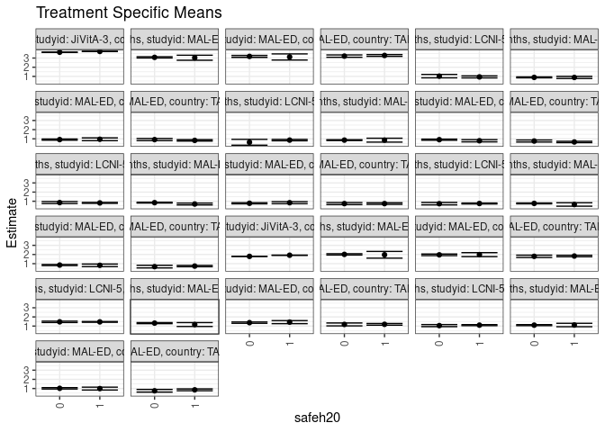

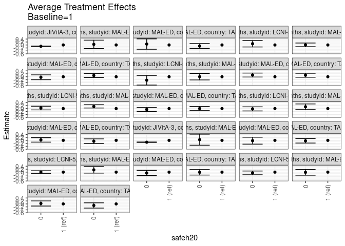

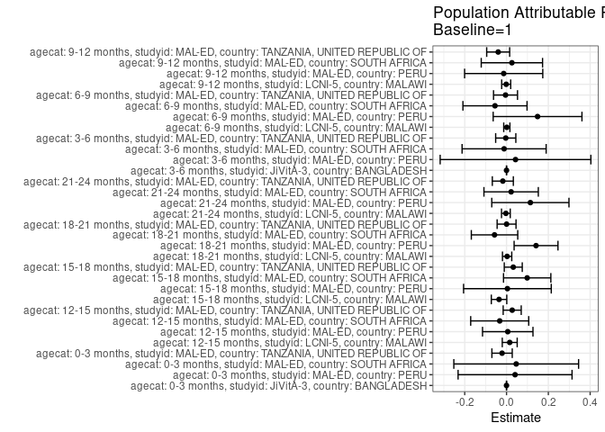

## Results Table

### Parameter: TSM

| agecat | studyid | country | intervention_level | baseline_level | estimate | ci_lower | ci_upper |
| --- | --- | --- | --- | --- | --- | --- | --- |
| 0-3 months | JiVitA-3 | BANGLADESH | 1 | NA | 3.7235665 | 3.7130009 | 3.7341321 |
| 0-3 months | JiVitA-3 | BANGLADESH | 0 | NA | 3.6369864 | 3.6270100 | 3.6469628 |
| 0-3 months | MAL-ED | PERU | 1 | NA | 3.0358305 | 2.7623825 | 3.3092785 |
| 0-3 months | MAL-ED | PERU | 0 | NA | 3.0779010 | 3.0085516 | 3.1472504 |
| 0-3 months | MAL-ED | SOUTH AFRICA | 1 | NA | 3.1207642 | 2.7867225 | 3.4548060 |
| 0-3 months | MAL-ED | SOUTH AFRICA | 0 | NA | 3.1817853 | 3.0762163 | 3.2873543 |
| 0-3 months | MAL-ED | TANZANIA, UNITED REPUBLIC OF | 1 | NA | 3.2845427 | 3.1867454 | 3.3823399 |
| 0-3 months | MAL-ED | TANZANIA, UNITED REPUBLIC OF | 0 | NA | 3.2146947 | 3.0854140 | 3.3439753 |
| 3-6 months | JiVitA-3 | BANGLADESH | 1 | NA | 1.9203144 | 1.9096043 | 1.9310245 |
| 3-6 months | JiVitA-3 | BANGLADESH | 0 | NA | 1.7945360 | 1.7842862 | 1.8047858 |
| 3-6 months | MAL-ED | PERU | 1 | NA | 1.9684174 | 1.6026783 | 2.3341566 |
| 3-6 months | MAL-ED | PERU | 0 | NA | 2.0127835 | 1.9428914 | 2.0826756 |
| 3-6 months | MAL-ED | SOUTH AFRICA | 1 | NA | 1.9851218 | 1.7686392 | 2.2016043 |
| 3-6 months | MAL-ED | SOUTH AFRICA | 0 | NA | 1.9625578 | 1.8745221 | 2.0505935 |
| 3-6 months | MAL-ED | TANZANIA, UNITED REPUBLIC OF | 1 | NA | 1.8323731 | 1.7507876 | 1.9139585 |
| 3-6 months | MAL-ED | TANZANIA, UNITED REPUBLIC OF | 0 | NA | 1.7992234 | 1.6732101 | 1.9252367 |
| 6-9 months | LCNI-5 | MALAWI | 1 | NA | 1.4575757 | 1.4160681 | 1.4990834 |
| 6-9 months | LCNI-5 | MALAWI | 0 | NA | 1.4629394 | 1.3859325 | 1.5399464 |
| 6-9 months | MAL-ED | PERU | 1 | NA | 1.1684070 | 0.9557718 | 1.3810422 |
| 6-9 months | MAL-ED | PERU | 0 | NA | 1.3225108 | 1.2653831 | 1.3796384 |
| 6-9 months | MAL-ED | SOUTH AFRICA | 1 | NA | 1.4321776 | 1.2671242 | 1.5972309 |
| 6-9 months | MAL-ED | SOUTH AFRICA | 0 | NA | 1.3736582 | 1.3026413 | 1.4446750 |
| 6-9 months | MAL-ED | TANZANIA, UNITED REPUBLIC OF | 1 | NA | 1.1916561 | 1.1004413 | 1.2828709 |
| 6-9 months | MAL-ED | TANZANIA, UNITED REPUBLIC OF | 0 | NA | 1.1797089 | 1.0206990 | 1.3387188 |
| 9-12 months | LCNI-5 | MALAWI | 1 | NA | 1.1024498 | 1.0473690 | 1.1575307 |
| 9-12 months | LCNI-5 | MALAWI | 0 | NA | 1.0514787 | 0.9384526 | 1.1645049 |
| 9-12 months | MAL-ED | PERU | 1 | NA | 1.1160877 | 0.9289289 | 1.3032464 |
| 9-12 months | MAL-ED | PERU | 0 | NA | 1.1019161 | 1.0482767 | 1.1555555 |
| 9-12 months | MAL-ED | SOUTH AFRICA | 1 | NA | 0.9889957 | 0.8322027 | 1.1457886 |
| 9-12 months | MAL-ED | SOUTH AFRICA | 0 | NA | 1.0192915 | 0.9473126 | 1.0912704 |
| 9-12 months | MAL-ED | TANZANIA, UNITED REPUBLIC OF | 1 | NA | 0.8555325 | 0.7559482 | 0.9551168 |
| 9-12 months | MAL-ED | TANZANIA, UNITED REPUBLIC OF | 0 | NA | 0.7505965 | 0.6060446 | 0.8951484 |
| 12-15 months | LCNI-5 | MALAWI | 1 | NA | 0.9425552 | 0.8329835 | 1.0521268 |
| 12-15 months | LCNI-5 | MALAWI | 0 | NA | 1.0271351 | 0.8408344 | 1.2134357 |
| 12-15 months | MAL-ED | PERU | 1 | NA | 0.8846595 | 0.7695897 | 0.9997294 |
| 12-15 months | MAL-ED | PERU | 0 | NA | 0.8907084 | 0.8410984 | 0.9403185 |
| 12-15 months | MAL-ED | SOUTH AFRICA | 1 | NA | 0.9498992 | 0.7980974 | 1.1017010 |
| 12-15 months | MAL-ED | SOUTH AFRICA | 0 | NA | 0.9141028 | 0.8510940 | 0.9771115 |
| 12-15 months | MAL-ED | TANZANIA, UNITED REPUBLIC OF | 1 | NA | 0.8271436 | 0.7493919 | 0.9048953 |
| 12-15 months | MAL-ED | TANZANIA, UNITED REPUBLIC OF | 0 | NA | 0.9127188 | 0.7956549 | 1.0297828 |
| 15-18 months | LCNI-5 | MALAWI | 1 | NA | 0.8586274 | 0.7855989 | 0.9316558 |
| 15-18 months | LCNI-5 | MALAWI | 0 | NA | 0.6247885 | 0.3068980 | 0.9426789 |
| 15-18 months | MAL-ED | PERU | 1 | NA | 0.8534728 | 0.6397559 | 1.0671898 |
| 15-18 months | MAL-ED | PERU | 0 | NA | 0.8578623 | 0.8135834 | 0.9021411 |
| 15-18 months | MAL-ED | SOUTH AFRICA | 1 | NA | 0.7885806 | 0.6698167 | 0.9073446 |
| 15-18 months | MAL-ED | SOUTH AFRICA | 0 | NA | 0.9048520 | 0.8462196 | 0.9634844 |
| 15-18 months | MAL-ED | TANZANIA, UNITED REPUBLIC OF | 1 | NA | 0.6541005 | 0.5803862 | 0.7278147 |
| 15-18 months | MAL-ED | TANZANIA, UNITED REPUBLIC OF | 0 | NA | 0.7569068 | 0.6454235 | 0.8683901 |
| 18-21 months | LCNI-5 | MALAWI | 1 | NA | 0.8170125 | 0.7654379 | 0.8685872 |
| 18-21 months | LCNI-5 | MALAWI | 0 | NA | 0.8509710 | 0.7379197 | 0.9640222 |
| 18-21 months | MAL-ED | PERU | 1 | NA | 0.6966493 | 0.5976815 | 0.7956172 |
| 18-21 months | MAL-ED | PERU | 0 | NA | 0.8438128 | 0.7975106 | 0.8901149 |
| 18-21 months | MAL-ED | SOUTH AFRICA | 1 | NA | 0.8384742 | 0.7269122 | 0.9500362 |
| 18-21 months | MAL-ED | SOUTH AFRICA | 0 | NA | 0.7777101 | 0.7147848 | 0.8406355 |
| 18-21 months | MAL-ED | TANZANIA, UNITED REPUBLIC OF | 1 | NA | 0.7411862 | 0.6545389 | 0.8278336 |
| 18-21 months | MAL-ED | TANZANIA, UNITED REPUBLIC OF | 0 | NA | 0.7410955 | 0.6329312 | 0.8492599 |
| 21-24 months | LCNI-5 | MALAWI | 1 | NA | 0.7536355 | 0.7042537 | 0.8030173 |
| 21-24 months | LCNI-5 | MALAWI | 0 | NA | 0.7314547 | 0.6020265 | 0.8608830 |
| 21-24 months | MAL-ED | PERU | 1 | NA | 0.6442119 | 0.4583975 | 0.8300263 |
| 21-24 months | MAL-ED | PERU | 0 | NA | 0.7627749 | 0.7144494 | 0.8111003 |
| 21-24 months | MAL-ED | SOUTH AFRICA | 1 | NA | 0.8175084 | 0.6792664 | 0.9557503 |
| 21-24 months | MAL-ED | SOUTH AFRICA | 0 | NA | 0.8468648 | 0.7903538 | 0.9033758 |
| 21-24 months | MAL-ED | TANZANIA, UNITED REPUBLIC OF | 1 | NA | 0.7352193 | 0.6649549 | 0.8054837 |
| 21-24 months | MAL-ED | TANZANIA, UNITED REPUBLIC OF | 0 | NA | 0.6755818 | 0.5335200 | 0.8176437 |

### Parameter: E(Y)

| agecat | studyid | country | intervention_level | baseline_level | estimate | ci_lower | ci_upper |
| --- | --- | --- | --- | --- | --- | --- | --- |
| 0-3 months | JiVitA-3 | BANGLADESH | NA | NA | 3.7234127 | 3.7131065 | 3.7337188 |
| 0-3 months | MAL-ED | PERU | NA | NA | 3.0766479 | 3.0096811 | 3.1436148 |
| 0-3 months | MAL-ED | SOUTH AFRICA | NA | NA | 3.1670516 | 3.0651964 | 3.2689068 |
| 0-3 months | MAL-ED | TANZANIA, UNITED REPUBLIC OF | NA | NA | 3.2631757 | 3.1854001 | 3.3409512 |
| 3-6 months | JiVitA-3 | BANGLADESH | NA | NA | 1.9201969 | 1.9097350 | 1.9306589 |
| 3-6 months | MAL-ED | PERU | NA | NA | 2.0114190 | 1.9435740 | 2.0792639 |
| 3-6 months | MAL-ED | SOUTH AFRICA | NA | NA | 1.9735408 | 1.8927925 | 2.0542892 |
| 3-6 months | MAL-ED | TANZANIA, UNITED REPUBLIC OF | NA | NA | 1.8286113 | 1.7605412 | 1.8966813 |
| 6-9 months | LCNI-5 | MALAWI | NA | NA | 1.4589363 | 1.4224162 | 1.4954563 |
| 6-9 months | MAL-ED | PERU | NA | NA | 1.3168407 | 1.2615074 | 1.3721740 |
| 6-9 months | MAL-ED | SOUTH AFRICA | NA | NA | 1.3769400 | 1.3125507 | 1.4413293 |
| 6-9 months | MAL-ED | TANZANIA, UNITED REPUBLIC OF | NA | NA | 1.1868199 | 1.1090396 | 1.2646002 |
| 9-12 months | LCNI-5 | MALAWI | NA | NA | 1.1007887 | 1.0539615 | 1.1476158 |
| 9-12 months | MAL-ED | PERU | NA | NA | 1.1024805 | 1.0504394 | 1.1545215 |
| 9-12 months | MAL-ED | SOUTH AFRICA | NA | NA | 1.0146639 | 0.9495597 | 1.0797680 |
| 9-12 months | MAL-ED | TANZANIA, UNITED REPUBLIC OF | NA | NA | 0.8155931 | 0.7342357 | 0.8969504 |
| 12-15 months | LCNI-5 | MALAWI | NA | NA | 0.9578403 | 0.8612449 | 1.0544357 |
| 12-15 months | MAL-ED | PERU | NA | NA | 0.8904833 | 0.8425275 | 0.9384392 |
| 12-15 months | MAL-ED | SOUTH AFRICA | NA | NA | 0.9172722 | 0.8595621 | 0.9749824 |
| 12-15 months | MAL-ED | TANZANIA, UNITED REPUBLIC OF | NA | NA | 0.8542196 | 0.7897390 | 0.9187003 |
| 15-18 months | LCNI-5 | MALAWI | NA | NA | 0.8227868 | 0.7513696 | 0.8942040 |
| 15-18 months | MAL-ED | PERU | NA | NA | 0.8576910 | 0.8143303 | 0.9010517 |
| 15-18 months | MAL-ED | SOUTH AFRICA | NA | NA | 0.8873549 | 0.8344616 | 0.9402481 |
| 15-18 months | MAL-ED | TANZANIA, UNITED REPUBLIC OF | NA | NA | 0.6862933 | 0.6249762 | 0.7476104 |
| 18-21 months | LCNI-5 | MALAWI | NA | NA | 0.8198090 | 0.7732927 | 0.8663254 |
| 18-21 months | MAL-ED | PERU | NA | NA | 0.8378061 | 0.7930237 | 0.8825886 |
| 18-21 months | MAL-ED | SOUTH AFRICA | NA | NA | 0.7810829 | 0.7253333 | 0.8368325 |
| 18-21 months | MAL-ED | TANZANIA, UNITED REPUBLIC OF | NA | NA | 0.7413740 | 0.6736807 | 0.8090672 |
| 21-24 months | LCNI-5 | MALAWI | NA | NA | 0.7505036 | 0.7048983 | 0.7961088 |
| 21-24 months | MAL-ED | PERU | NA | NA | 0.7582148 | 0.7110844 | 0.8053451 |
| 21-24 months | MAL-ED | SOUTH AFRICA | NA | NA | 0.8395115 | 0.7878135 | 0.8912095 |
| 21-24 months | MAL-ED | TANZANIA, UNITED REPUBLIC OF | NA | NA | 0.7174798 | 0.6527204 | 0.7822392 |

### Parameter: ATE

| agecat | studyid | country | intervention_level | baseline_level | estimate | ci_lower | ci_upper |
| --- | --- | --- | --- | --- | --- | --- | --- |
| 0-3 months | JiVitA-3 | BANGLADESH | 1 | 1 | 0.0000000 | 0.0000000 | 0.0000000 |
| 0-3 months | JiVitA-3 | BANGLADESH | 0 | 1 | -0.0865801 | -0.1010105 | -0.0721496 |
| 0-3 months | MAL-ED | PERU | 1 | 1 | 0.0000000 | 0.0000000 | 0.0000000 |
| 0-3 months | MAL-ED | PERU | 0 | 1 | 0.0420705 | -0.2402156 | 0.3243566 |
| 0-3 months | MAL-ED | SOUTH AFRICA | 1 | 1 | 0.0000000 | 0.0000000 | 0.0000000 |
| 0-3 months | MAL-ED | SOUTH AFRICA | 0 | 1 | 0.0610210 | -0.2897083 | 0.4117504 |
| 0-3 months | MAL-ED | TANZANIA, UNITED REPUBLIC OF | 1 | 1 | 0.0000000 | 0.0000000 | 0.0000000 |
| 0-3 months | MAL-ED | TANZANIA, UNITED REPUBLIC OF | 0 | 1 | -0.0698480 | -0.2324908 | 0.0927948 |
| 3-6 months | JiVitA-3 | BANGLADESH | 1 | 1 | 0.0000000 | 0.0000000 | 0.0000000 |
| 3-6 months | JiVitA-3 | BANGLADESH | 0 | 1 | -0.1257784 | -0.1399992 | -0.1115576 |
| 3-6 months | MAL-ED | PERU | 1 | 1 | 0.0000000 | 0.0000000 | 0.0000000 |
| 3-6 months | MAL-ED | PERU | 0 | 1 | 0.0443661 | -0.3279640 | 0.4166962 |
| 3-6 months | MAL-ED | SOUTH AFRICA | 1 | 1 | 0.0000000 | 0.0000000 | 0.0000000 |
| 3-6 months | MAL-ED | SOUTH AFRICA | 0 | 1 | -0.0225640 | -0.2570853 | 0.2119574 |
| 3-6 months | MAL-ED | TANZANIA, UNITED REPUBLIC OF | 1 | 1 | 0.0000000 | 0.0000000 | 0.0000000 |
| 3-6 months | MAL-ED | TANZANIA, UNITED REPUBLIC OF | 0 | 1 | -0.0331497 | -0.1837622 | 0.1174628 |
| 6-9 months | LCNI-5 | MALAWI | 1 | 1 | 0.0000000 | 0.0000000 | 0.0000000 |
| 6-9 months | LCNI-5 | MALAWI | 0 | 1 | 0.0053637 | -0.0825101 | 0.0932374 |
| 6-9 months | MAL-ED | PERU | 1 | 1 | 0.0000000 | 0.0000000 | 0.0000000 |
| 6-9 months | MAL-ED | PERU | 0 | 1 | 0.1541038 | -0.0659244 | 0.3741319 |
| 6-9 months | MAL-ED | SOUTH AFRICA | 1 | 1 | 0.0000000 | 0.0000000 | 0.0000000 |
| 6-9 months | MAL-ED | SOUTH AFRICA | 0 | 1 | -0.0585194 | -0.2384699 | 0.1214311 |
| 6-9 months | MAL-ED | TANZANIA, UNITED REPUBLIC OF | 1 | 1 | 0.0000000 | 0.0000000 | 0.0000000 |
| 6-9 months | MAL-ED | TANZANIA, UNITED REPUBLIC OF | 0 | 1 | -0.0119472 | -0.1974509 | 0.1735564 |
| 9-12 months | LCNI-5 | MALAWI | 1 | 1 | 0.0000000 | 0.0000000 | 0.0000000 |
| 9-12 months | LCNI-5 | MALAWI | 0 | 1 | -0.0509711 | -0.1778432 | 0.0759010 |
| 9-12 months | MAL-ED | PERU | 1 | 1 | 0.0000000 | 0.0000000 | 0.0000000 |
| 9-12 months | MAL-ED | PERU | 0 | 1 | -0.0141716 | -0.2088651 | 0.1805220 |
| 9-12 months | MAL-ED | SOUTH AFRICA | 1 | 1 | 0.0000000 | 0.0000000 | 0.0000000 |
| 9-12 months | MAL-ED | SOUTH AFRICA | 0 | 1 | 0.0302958 | -0.1424783 | 0.2030700 |
| 9-12 months | MAL-ED | TANZANIA, UNITED REPUBLIC OF | 1 | 1 | 0.0000000 | 0.0000000 | 0.0000000 |
| 9-12 months | MAL-ED | TANZANIA, UNITED REPUBLIC OF | 0 | 1 | -0.1049360 | -0.2822864 | 0.0724144 |
| 12-15 months | LCNI-5 | MALAWI | 1 | 1 | 0.0000000 | 0.0000000 | 0.0000000 |
| 12-15 months | LCNI-5 | MALAWI | 0 | 1 | 0.0845799 | -0.1337868 | 0.3029466 |
| 12-15 months | MAL-ED | PERU | 1 | 1 | 0.0000000 | 0.0000000 | 0.0000000 |
| 12-15 months | MAL-ED | PERU | 0 | 1 | 0.0060489 | -0.1192597 | 0.1313574 |
| 12-15 months | MAL-ED | SOUTH AFRICA | 1 | 1 | 0.0000000 | 0.0000000 | 0.0000000 |
| 12-15 months | MAL-ED | SOUTH AFRICA | 0 | 1 | -0.0357965 | -0.2001957 | 0.1286028 |
| 12-15 months | MAL-ED | TANZANIA, UNITED REPUBLIC OF | 1 | 1 | 0.0000000 | 0.0000000 | 0.0000000 |
| 12-15 months | MAL-ED | TANZANIA, UNITED REPUBLIC OF | 0 | 1 | 0.0855752 | -0.0553997 | 0.2265502 |
| 15-18 months | LCNI-5 | MALAWI | 1 | 1 | 0.0000000 | 0.0000000 | 0.0000000 |
| 15-18 months | LCNI-5 | MALAWI | 0 | 1 | -0.2338389 | -0.5603476 | 0.0926697 |
| 15-18 months | MAL-ED | PERU | 1 | 1 | 0.0000000 | 0.0000000 | 0.0000000 |
| 15-18 months | MAL-ED | PERU | 0 | 1 | 0.0043894 | -0.2138663 | 0.2226452 |
| 15-18 months | MAL-ED | SOUTH AFRICA | 1 | 1 | 0.0000000 | 0.0000000 | 0.0000000 |
| 15-18 months | MAL-ED | SOUTH AFRICA | 0 | 1 | 0.1162713 | -0.0174949 | 0.2500375 |
| 15-18 months | MAL-ED | TANZANIA, UNITED REPUBLIC OF | 1 | 1 | 0.0000000 | 0.0000000 | 0.0000000 |
| 15-18 months | MAL-ED | TANZANIA, UNITED REPUBLIC OF | 0 | 1 | 0.1028063 | -0.0312844 | 0.2368970 |
| 18-21 months | LCNI-5 | MALAWI | 1 | 1 | 0.0000000 | 0.0000000 | 0.0000000 |
| 18-21 months | LCNI-5 | MALAWI | 0 | 1 | 0.0339584 | -0.0914313 | 0.1593482 |
| 18-21 months | MAL-ED | PERU | 1 | 1 | 0.0000000 | 0.0000000 | 0.0000000 |
| 18-21 months | MAL-ED | PERU | 0 | 1 | 0.1471634 | 0.0378999 | 0.2564270 |
| 18-21 months | MAL-ED | SOUTH AFRICA | 1 | 1 | 0.0000000 | 0.0000000 | 0.0000000 |
| 18-21 months | MAL-ED | SOUTH AFRICA | 0 | 1 | -0.0607640 | -0.1900978 | 0.0685698 |
| 18-21 months | MAL-ED | TANZANIA, UNITED REPUBLIC OF | 1 | 1 | 0.0000000 | 0.0000000 | 0.0000000 |
| 18-21 months | MAL-ED | TANZANIA, UNITED REPUBLIC OF | 0 | 1 | -0.0000907 | -0.1394702 | 0.1392888 |
| 21-24 months | LCNI-5 | MALAWI | 1 | 1 | 0.0000000 | 0.0000000 | 0.0000000 |
| 21-24 months | LCNI-5 | MALAWI | 0 | 1 | -0.0221807 | -0.1614481 | 0.1170866 |
| 21-24 months | MAL-ED | PERU | 1 | 1 | 0.0000000 | 0.0000000 | 0.0000000 |
| 21-24 months | MAL-ED | PERU | 0 | 1 | 0.1185629 | -0.0734327 | 0.3105586 |
| 21-24 months | MAL-ED | SOUTH AFRICA | 1 | 1 | 0.0000000 | 0.0000000 | 0.0000000 |
| 21-24 months | MAL-ED | SOUTH AFRICA | 0 | 1 | 0.0293564 | -0.1200844 | 0.1787973 |
| 21-24 months | MAL-ED | TANZANIA, UNITED REPUBLIC OF | 1 | 1 | 0.0000000 | 0.0000000 | 0.0000000 |
| 21-24 months | MAL-ED | TANZANIA, UNITED REPUBLIC OF | 0 | 1 | -0.0596375 | -0.2187251 | 0.0994501 |

### Parameter: PAR

| agecat | studyid | country | intervention_level | baseline_level | estimate | ci_lower | ci_upper |
| --- | --- | --- | --- | --- | --- | --- | --- |
| 0-3 months | JiVitA-3 | BANGLADESH | 1 | NA | -0.0001538 | -0.0005122 | 0.0002045 |
| 0-3 months | MAL-ED | PERU | 1 | NA | 0.0408174 | -0.2317261 | 0.3133610 |
| 0-3 months | MAL-ED | SOUTH AFRICA | 1 | NA | 0.0462874 | -0.2521154 | 0.3446901 |
| 0-3 months | MAL-ED | TANZANIA, UNITED REPUBLIC OF | 1 | NA | -0.0213670 | -0.0700230 | 0.0272889 |
| 3-6 months | JiVitA-3 | BANGLADESH | 1 | NA | -0.0001174 | -0.0004739 | 0.0002390 |
| 3-6 months | MAL-ED | PERU | 1 | NA | 0.0430015 | -0.3175018 | 0.4035049 |
| 3-6 months | MAL-ED | SOUTH AFRICA | 1 | NA | -0.0115809 | -0.2126703 | 0.1895085 |
| 3-6 months | MAL-ED | TANZANIA, UNITED REPUBLIC OF | 1 | NA | -0.0037618 | -0.0519888 | 0.0444653 |
| 6-9 months | LCNI-5 | MALAWI | 1 | NA | 0.0013605 | -0.0134308 | 0.0161518 |
| 6-9 months | MAL-ED | PERU | 1 | NA | 0.1484337 | -0.0639026 | 0.3607700 |
| 6-9 months | MAL-ED | SOUTH AFRICA | 1 | NA | -0.0552376 | -0.2086078 | 0.0981326 |
| 6-9 months | MAL-ED | TANZANIA, UNITED REPUBLIC OF | 1 | NA | -0.0048362 | -0.0621768 | 0.0525043 |
| 9-12 months | LCNI-5 | MALAWI | 1 | NA | -0.0016612 | -0.0232069 | 0.0198845 |
| 9-12 months | MAL-ED | PERU | 1 | NA | -0.0136072 | -0.2005478 | 0.1733334 |
| 9-12 months | MAL-ED | SOUTH AFRICA | 1 | NA | 0.0256682 | -0.1210153 | 0.1723517 |
| 9-12 months | MAL-ED | TANZANIA, UNITED REPUBLIC OF | 1 | NA | -0.0399395 | -0.0948378 | 0.0149589 |
| 12-15 months | LCNI-5 | MALAWI | 1 | NA | 0.0152851 | -0.0204033 | 0.0509736 |
| 12-15 months | MAL-ED | PERU | 1 | NA | 0.0058238 | -0.1148222 | 0.1264698 |
| 12-15 months | MAL-ED | SOUTH AFRICA | 1 | NA | -0.0326270 | -0.1714344 | 0.1061804 |
| 12-15 months | MAL-ED | TANZANIA, UNITED REPUBLIC OF | 1 | NA | 0.0270760 | -0.0160640 | 0.0702161 |
| 15-18 months | LCNI-5 | MALAWI | 1 | NA | -0.0358406 | -0.0728075 | 0.0011262 |
| 15-18 months | MAL-ED | PERU | 1 | NA | 0.0042181 | -0.2055203 | 0.2139566 |
| 15-18 months | MAL-ED | SOUTH AFRICA | 1 | NA | 0.0987742 | -0.0144250 | 0.2119734 |
| 15-18 months | MAL-ED | TANZANIA, UNITED REPUBLIC OF | 1 | NA | 0.0321928 | -0.0108210 | 0.0752067 |
| 18-21 months | LCNI-5 | MALAWI | 1 | NA | 0.0027965 | -0.0194153 | 0.0250084 |
| 18-21 months | MAL-ED | PERU | 1 | NA | 0.1411568 | 0.0362733 | 0.2460402 |
| 18-21 months | MAL-ED | SOUTH AFRICA | 1 | NA | -0.0573913 | -0.1684153 | 0.0536328 |
| 18-21 months | MAL-ED | TANZANIA, UNITED REPUBLIC OF | 1 | NA | 0.0001877 | -0.0450097 | 0.0453851 |
| 21-24 months | LCNI-5 | MALAWI | 1 | NA | -0.0031319 | -0.0239924 | 0.0177286 |
| 21-24 months | MAL-ED | PERU | 1 | NA | 0.1140028 | -0.0706383 | 0.2986439 |
| 21-24 months | MAL-ED | SOUTH AFRICA | 1 | NA | 0.0220032 | -0.1080298 | 0.1520361 |
| 21-24 months | MAL-ED | TANZANIA, UNITED REPUBLIC OF | 1 | NA | -0.0177396 | -0.0680064 | 0.0325273 |